# Risk Factor Analysis

## Outcome Variable

**Outcome Variable:** stunted

## Predictor Variables

**Intervention Variable:** enwast

**Adjustment Set:**

unadjusted

## Stratifying Variables

The analysis was stratified on these variable(s):

- agecat
- studyid
- country

## Data Summary

| agecat | studyid | country | enwast | stunted | n_cell | n |
| --- | --- | --- | --- | --- | --- | --- |
| Birth | ki0047075b-MAL-ED | BANGLADESH | 0 | 0 | 174 | 241 |
| Birth | ki0047075b-MAL-ED | BANGLADESH | 0 | 1 | 27 | 241 |
| Birth | ki0047075b-MAL-ED | BANGLADESH | 1 | 0 | 36 | 241 |
| Birth | ki0047075b-MAL-ED | BANGLADESH | 1 | 1 | 4 | 241 |
| 6 months | ki0047075b-MAL-ED | BANGLADESH | 0 | 0 | 152 | 221 |
| 6 months | ki0047075b-MAL-ED | BANGLADESH | 0 | 1 | 30 | 221 |
| 6 months | ki0047075b-MAL-ED | BANGLADESH | 1 | 0 | 33 | 221 |
| 6 months | ki0047075b-MAL-ED | BANGLADESH | 1 | 1 | 6 | 221 |
| 24 months | ki0047075b-MAL-ED | BANGLADESH | 0 | 0 | 90 | 195 |
| 24 months | ki0047075b-MAL-ED | BANGLADESH | 0 | 1 | 70 | 195 |
| 24 months | ki0047075b-MAL-ED | BANGLADESH | 1 | 0 | 22 | 195 |
| 24 months | ki0047075b-MAL-ED | BANGLADESH | 1 | 1 | 13 | 195 |
| Birth | ki0047075b-MAL-ED | BRAZIL | 0 | 0 | 163 | 183 |
| Birth | ki0047075b-MAL-ED | BRAZIL | 0 | 1 | 14 | 183 |
| Birth | ki0047075b-MAL-ED | BRAZIL | 1 | 0 | 6 | 183 |
| Birth | ki0047075b-MAL-ED | BRAZIL | 1 | 1 | 0 | 183 |
| 6 months | ki0047075b-MAL-ED | BRAZIL | 0 | 0 | 156 | 166 |
| 6 months | ki0047075b-MAL-ED | BRAZIL | 0 | 1 | 4 | 166 |
| 6 months | ki0047075b-MAL-ED | BRAZIL | 1 | 0 | 6 | 166 |
| 6 months | ki0047075b-MAL-ED | BRAZIL | 1 | 1 | 0 | 166 |
| 24 months | ki0047075b-MAL-ED | BRAZIL | 0 | 0 | 122 | 133 |
| 24 months | ki0047075b-MAL-ED | BRAZIL | 0 | 1 | 6 | 133 |
| 24 months | ki0047075b-MAL-ED | BRAZIL | 1 | 0 | 5 | 133 |
| 24 months | ki0047075b-MAL-ED | BRAZIL | 1 | 1 | 0 | 133 |
| Birth | ki0047075b-MAL-ED | INDIA | 0 | 0 | 146 | 203 |
| Birth | ki0047075b-MAL-ED | INDIA | 0 | 1 | 24 | 203 |
| Birth | ki0047075b-MAL-ED | INDIA | 1 | 0 | 27 | 203 |
| Birth | ki0047075b-MAL-ED | INDIA | 1 | 1 | 6 | 203 |
| 6 months | ki0047075b-MAL-ED | INDIA | 0 | 0 | 129 | 189 |
| 6 months | ki0047075b-MAL-ED | INDIA | 0 | 1 | 30 | 189 |

[output cut: 280 more lines]

The following strata were considered:

- agecat: 24 months, studyid: ki0047075b-MAL-ED, country: BANGLADESH
- agecat: 24 months, studyid: ki0047075b-MAL-ED, country: BRAZIL
- agecat: 24 months, studyid: ki0047075b-MAL-ED, country: INDIA
- agecat: 24 months, studyid: ki0047075b-MAL-ED, country: NEPAL
- agecat: 24 months, studyid: ki0047075b-MAL-ED, country: PERU
- agecat: 24 months, studyid: ki0047075b-MAL-ED, country: SOUTH AFRICA
- agecat: 24 months, studyid: ki0047075b-MAL-ED, country: TANZANIA, UNITED REPUBLIC OF
- agecat: 24 months, studyid: ki1000108-CMC-V-BCS-2002, country: INDIA
- agecat: 24 months, studyid: ki1000108-IRC, country: INDIA
- agecat: 24 months, studyid: ki1017093-NIH-Birth, country: BANGLADESH
- agecat: 24 months, studyid: ki1017093c-NIH-Crypto, country: BANGLADESH
- agecat: 24 months, studyid: ki1101329-Keneba, country: GAMBIA
- agecat: 24 months, studyid: ki1113344-GMS-Nepal, country: NEPAL
- agecat: 24 months, studyid: ki1114097-CMIN, country: GUINEA-BISSAU
- agecat: 24 months, studyid: ki1114097-CMIN, country: PERU
- agecat: 24 months, studyid: ki1114097-CONTENT, country: PERU
- agecat: 24 months, studyid: ki1119695-PROBIT, country: BELARUS
- agecat: 24 months, studyid: ki1126311-ZVITAMBO, country: ZIMBABWE
- agecat: 24 months, studyid: ki1135781-COHORTS, country: GUATEMALA
- agecat: 24 months, studyid: ki1135781-COHORTS, country: INDIA
- agecat: 24 months, studyid: ki1135781-COHORTS, country: PHILIPPINES
- agecat: 24 months, studyid: ki1148112-LCNI-5, country: MALAWI
- agecat: 24 months, studyid: kiGH5241-JiVitA-3, country: BANGLADESH
- agecat: 24 months, studyid: kiGH5241-JiVitA-4, country: BANGLADESH
- agecat: 6 months, studyid: ki0047075b-MAL-ED, country: BANGLADESH
- agecat: 6 months, studyid: ki0047075b-MAL-ED, country: BRAZIL
- agecat: 6 months, studyid: ki0047075b-MAL-ED, country: INDIA
- agecat: 6 months, studyid: ki0047075b-MAL-ED, country: NEPAL
- agecat: 6 months, studyid: ki0047075b-MAL-ED, country: PERU
- agecat: 6 months, studyid: ki0047075b-MAL-ED, country: SOUTH AFRICA
- agecat: 6 months, studyid: ki0047075b-MAL-ED, country: TANZANIA, UNITED REPUBLIC OF
- agecat: 6 months, studyid: ki1000108-CMC-V-BCS-2002, country: INDIA
- agecat: 6 months, studyid: ki1000108-IRC, country: INDIA
- agecat: 6 months, studyid: ki1000109-EE, country: PAKISTAN
- agecat: 6 months, studyid: ki1000109-ResPak, country: PAKISTAN
- agecat: 6 months, studyid: ki1000304b-SAS-CompFeed, country: INDIA
- agecat: 6 months, studyid: ki1000304b-SAS-FoodSuppl, country: INDIA
- agecat: 6 months, studyid: ki1017093-NIH-Birth, country: BANGLADESH
- agecat: 6 months, studyid: ki1017093c-NIH-Crypto, country: BANGLADESH
- agecat: 6 months, studyid: ki1066203-TanzaniaChild2, country: TANZANIA, UNITED REPUBLIC OF
- agecat: 6 months, studyid: ki1101329-Keneba, country: GAMBIA
- agecat: 6 months, studyid: ki1112895-Guatemala BSC, country: GUATEMALA
- agecat: 6 months, studyid: ki1113344-GMS-Nepal, country: NEPAL
- agecat: 6 months, studyid: ki1114097-CMIN, country: BRAZIL
- agecat: 6 months, studyid: ki1114097-CMIN, country: GUINEA-BISSAU
- agecat: 6 months, studyid: ki1114097-CMIN, country: PERU
- agecat: 6 months, studyid: ki1114097-CONTENT, country: PERU
- agecat: 6 months, studyid: ki1119695-PROBIT, country: BELARUS
- agecat: 6 months, studyid: ki1126311-ZVITAMBO, country: ZIMBABWE
- agecat: 6 months, studyid: ki1135781-COHORTS, country: GUATEMALA
- agecat: 6 months, studyid: ki1135781-COHORTS, country: INDIA
- agecat: 6 months, studyid: ki1135781-COHORTS, country: PHILIPPINES
- agecat: 6 months, studyid: ki1148112-LCNI-5, country: MALAWI
- agecat: 6 months, studyid: kiGH5241-JiVitA-3, country: BANGLADESH
- agecat: 6 months, studyid: kiGH5241-JiVitA-4, country: BANGLADESH
- agecat: Birth, studyid: ki0047075b-MAL-ED, country: BANGLADESH
- agecat: Birth, studyid: ki0047075b-MAL-ED, country: BRAZIL
- agecat: Birth, studyid: ki0047075b-MAL-ED, country: INDIA
- agecat: Birth, studyid: ki0047075b-MAL-ED, country: NEPAL
- agecat: Birth, studyid: ki0047075b-MAL-ED, country: PERU
- agecat: Birth, studyid: ki0047075b-MAL-ED, country: SOUTH AFRICA
- agecat: Birth, studyid: ki0047075b-MAL-ED, country: TANZANIA, UNITED REPUBLIC OF
- agecat: Birth, studyid: ki1000108-CMC-V-BCS-2002, country: INDIA
- agecat: Birth, studyid: ki1000108-IRC, country: INDIA
- agecat: Birth, studyid: ki1000109-EE, country: PAKISTAN
- agecat: Birth, studyid: ki1000109-ResPak, country: PAKISTAN
- agecat: Birth, studyid: ki1000304b-SAS-CompFeed, country: INDIA
- agecat: Birth, studyid: ki1017093-NIH-Birth, country: BANGLADESH
- agecat: Birth, studyid: ki1017093c-NIH-Crypto, country: BANGLADESH
- agecat: Birth, studyid: ki1101329-Keneba, country: GAMBIA
- agecat: Birth, studyid: ki1114097-CMIN, country: BANGLADESH
- agecat: Birth, studyid: ki1114097-CMIN, country: BRAZIL
- agecat: Birth, studyid: ki1114097-CMIN, country: PERU
- agecat: Birth, studyid: ki1114097-CONTENT, country: PERU
- agecat: Birth, studyid: ki1119695-PROBIT, country: BELARUS
- agecat: Birth, studyid: ki1126311-ZVITAMBO, country: ZIMBABWE
- agecat: Birth, studyid: ki1135781-COHORTS, country: GUATEMALA
- agecat: Birth, studyid: ki1135781-COHORTS, country: INDIA
- agecat: Birth, studyid: ki1135781-COHORTS, country: PHILIPPINES
- agecat: Birth, studyid: kiGH5241-JiVitA-3, country: BANGLADESH
- agecat: Birth, studyid: kiGH5241-JiVitA-4, country: BANGLADESH

### Dropped Strata

Some strata were dropped due to rare outcomes:

- agecat: Birth, studyid: ki0047075b-MAL-ED, country: BANGLADESH
- agecat: Birth, studyid: ki0047075b-MAL-ED, country: BRAZIL
- agecat: 6 months, studyid: ki0047075b-MAL-ED, country: BRAZIL
- agecat: 24 months, studyid: ki0047075b-MAL-ED, country: BRAZIL
- agecat: Birth, studyid: ki0047075b-MAL-ED, country: NEPAL
- agecat: 6 months, studyid: ki0047075b-MAL-ED, country: NEPAL
- agecat: Birth, studyid: ki0047075b-MAL-ED, country: PERU
- agecat: 6 months, studyid: ki0047075b-MAL-ED, country: PERU
- agecat: 24 months, studyid: ki0047075b-MAL-ED, country: PERU
- agecat: Birth, studyid: ki0047075b-MAL-ED, country: SOUTH AFRICA
- agecat: 6 months, studyid: ki0047075b-MAL-ED, country: SOUTH AFRICA
- agecat: 24 months, studyid: ki0047075b-MAL-ED, country: SOUTH AFRICA
- agecat: Birth, studyid: ki0047075b-MAL-ED, country: TANZANIA, UNITED REPUBLIC OF
- agecat: 6 months, studyid: ki0047075b-MAL-ED, country: TANZANIA, UNITED REPUBLIC OF
- agecat: 24 months, studyid: ki0047075b-MAL-ED, country: TANZANIA, UNITED REPUBLIC OF
- agecat: Birth, studyid: ki1000108-CMC-V-BCS-2002, country: INDIA
- agecat: 6 months, studyid: ki1000108-CMC-V-BCS-2002, country: INDIA
- agecat: 24 months, studyid: ki1000108-CMC-V-BCS-2002, country: INDIA
- agecat: Birth, studyid: ki1000108-IRC, country: INDIA
- agecat: 6 months, studyid: ki1000109-EE, country: PAKISTAN
- agecat: Birth, studyid: ki1000109-EE, country: PAKISTAN
- agecat: Birth, studyid: ki1000109-ResPak, country: PAKISTAN
- agecat: Birth, studyid: ki1000304b-SAS-CompFeed, country: INDIA
- agecat: Birth, studyid: ki1017093-NIH-Birth, country: BANGLADESH
- agecat: Birth, studyid: ki1017093c-NIH-Crypto, country: BANGLADESH
- agecat: 6 months, studyid: ki1017093c-NIH-Crypto, country: BANGLADESH
- agecat: 24 months, studyid: ki1017093c-NIH-Crypto, country: BANGLADESH
- agecat: 6 months, studyid: ki1066203-TanzaniaChild2, country: TANZANIA, UNITED REPUBLIC OF
- agecat: Birth, studyid: ki1101329-Keneba, country: GAMBIA
- agecat: 6 months, studyid: ki1112895-Guatemala BSC, country: GUATEMALA
- agecat: 6 months, studyid: ki1113344-GMS-Nepal, country: NEPAL
- agecat: 24 months, studyid: ki1113344-GMS-Nepal, country: NEPAL
- agecat: Birth, studyid: ki1114097-CMIN, country: BANGLADESH
- agecat: Birth, studyid: ki1114097-CMIN, country: BRAZIL
- agecat: 6 months, studyid: ki1114097-CMIN, country: BRAZIL
- agecat: 24 months, studyid: ki1114097-CMIN, country: GUINEA-BISSAU
- agecat: 6 months, studyid: ki1114097-CMIN, country: GUINEA-BISSAU
- agecat: 6 months, studyid: ki1114097-CMIN, country: PERU
- agecat: 24 months, studyid: ki1114097-CMIN, country: PERU
- agecat: Birth, studyid: ki1114097-CONTENT, country: PERU
- agecat: Birth, studyid: ki1119695-PROBIT, country: BELARUS
- agecat: Birth, studyid: ki1135781-COHORTS, country: GUATEMALA
- agecat: 24 months, studyid: ki1148112-LCNI-5, country: MALAWI

## Methods Detail

We’re interested in the causal parameters $E[Y_a]$ for all values of $a \in \mathcal{A}$. These parameters represent the mean outcome if, possibly contrary to fact, we intervened to set all units to have $A=a$. Under the randomization and positivity assumptions, these are identified by the statistical parameters $\psi_a=E_W[E_{Y|A,W}(Y|A=a,W)]$. In addition, we’re interested in the mean of $Y$, $E[Y]$ under no intervention (the observed mean). We will estimate these parameters by using SuperLearner to fit the relevant likelihood factors – $E_{Y|A,W}(Y|A=a,W)$ and $p(A=a|W)$, and then updating our likelihood fit using a joint TMLE.

For unadjusted analyses ($W=\{\}$), initial likelihoods were estimated using Lrnr_glm to estimate the simple $E(Y|A)$ and Lrnr_mean to estimate $p(A)$. For adjusted analyses, a small library containing Lrnr_glmnet, Lrnr_xgboost, and Lrnr_mean was used.

Having estimated these parameters, we will then use the delta method to estimate relative risks and attributable risks relative to a prespecified baseline level of $A$.

```
##       stunted
## enwast  0  1
##      0 39  7
##      1  0  0
##       stunted
## enwast  0  1
##      0 48  7
##      1  0  0
##       stunted
## enwast  0
##      0 10
##      1  0
```

# Results Detail

## Results Plots

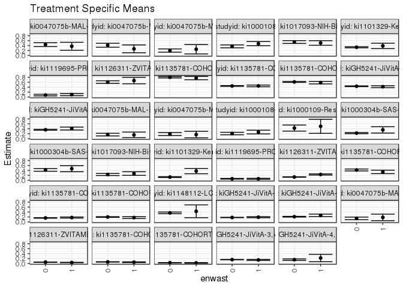

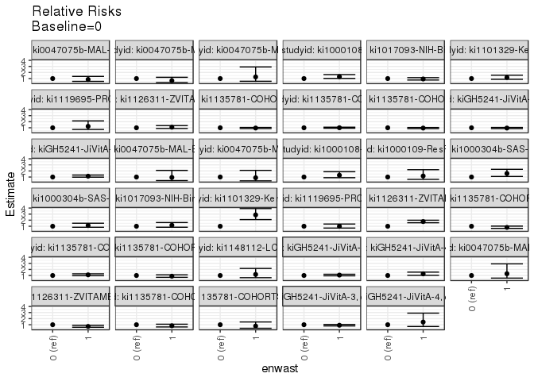

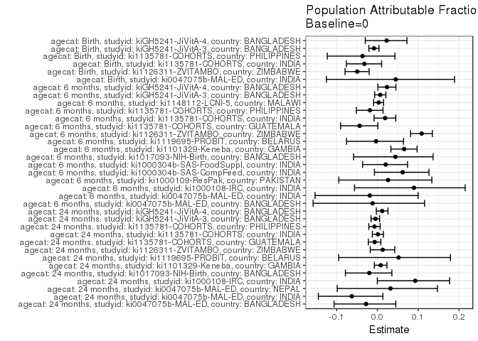

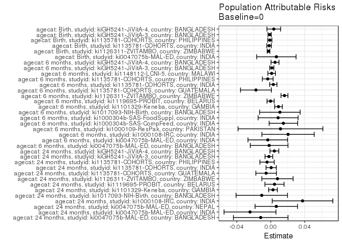

## Results Table

### Parameter: TSM

| agecat | studyid | country | intervention_level | baseline_level | estimate | ci_lower | ci_upper |
| --- | --- | --- | --- | --- | --- | --- | --- |
| Birth | ki0047075b-MAL-ED | INDIA | 0 | NA | 0.1411765 | 0.0887043 | 0.1936486 |
| Birth | ki0047075b-MAL-ED | INDIA | 1 | NA | 0.1818182 | 0.0498993 | 0.3137371 |
| Birth | ki1126311-ZVITAMBO | ZIMBABWE | 0 | NA | 0.0556374 | 0.0513254 | 0.0599495 |
| Birth | ki1126311-ZVITAMBO | ZIMBABWE | 1 | NA | 0.0402505 | 0.0321035 | 0.0483974 |
| Birth | ki1135781-COHORTS | INDIA | 0 | NA | 0.0637630 | 0.0570548 | 0.0704711 |
| Birth | ki1135781-COHORTS | INDIA | 1 | NA | 0.0529101 | 0.0398802 | 0.0659400 |
| Birth | ki1135781-COHORTS | PHILIPPINES | 0 | NA | 0.0306373 | 0.0238094 | 0.0374651 |
| Birth | ki1135781-COHORTS | PHILIPPINES | 1 | NA | 0.0238095 | 0.0099054 | 0.0377137 |
| Birth | kiGH5241-JiVitA-3 | BANGLADESH | 0 | NA | 0.1582060 | 0.1515864 | 0.1648256 |
| Birth | kiGH5241-JiVitA-3 | BANGLADESH | 1 | NA | 0.1446174 | 0.1256148 | 0.1636201 |
| Birth | kiGH5241-JiVitA-4 | BANGLADESH | 0 | NA | 0.1545595 | 0.1236384 | 0.1854806 |
| Birth | kiGH5241-JiVitA-4 | BANGLADESH | 1 | NA | 0.2222222 | 0.0728779 | 0.3715666 |
| 6 months | ki0047075b-MAL-ED | BANGLADESH | 0 | NA | 0.1648352 | 0.1108085 | 0.2188618 |
| 6 months | ki0047075b-MAL-ED | BANGLADESH | 1 | NA | 0.1538462 | 0.0403533 | 0.2673390 |
| 6 months | ki0047075b-MAL-ED | INDIA | 0 | NA | 0.1886792 | 0.1277031 | 0.2496554 |
| 6 months | ki0047075b-MAL-ED | INDIA | 1 | NA | 0.1666667 | 0.0329538 | 0.3003795 |
| 6 months | ki1000108-IRC | INDIA | 0 | NA | 0.2070313 | 0.1573336 | 0.2567289 |
| 6 months | ki1000108-IRC | INDIA | 1 | NA | 0.2671756 | 0.1913051 | 0.3430460 |
| 6 months | ki1000109-ResPak | PAKISTAN | 0 | NA | 0.4285714 | 0.3055488 | 0.5515941 |
| 6 months | ki1000109-ResPak | PAKISTAN | 1 | NA | 0.5000000 | 0.2151985 | 0.7848015 |
| 6 months | ki1000304b-SAS-CompFeed | INDIA | 0 | NA | 0.2250233 | 0.2012769 | 0.2487698 |
| 6 months | ki1000304b-SAS-CompFeed | INDIA | 1 | NA | 0.3550725 | 0.2274837 | 0.4826613 |
| 6 months | ki1000304b-SAS-FoodSuppl | INDIA | 0 | NA | 0.4191419 | 0.3635086 | 0.4747752 |
| 6 months | ki1000304b-SAS-FoodSuppl | INDIA | 1 | NA | 0.4687500 | 0.3463248 | 0.5911752 |
| 6 months | ki1017093-NIH-Birth | BANGLADESH | 0 | NA | 0.2343324 | 0.1909536 | 0.2777112 |
| 6 months | ki1017093-NIH-Birth | BANGLADESH | 1 | NA | 0.2727273 | 0.1996606 | 0.3457939 |
| 6 months | ki1101329-Keneba | GAMBIA | 0 | NA | 0.1295648 | 0.1148397 | 0.1442899 |
| 6 months | ki1101329-Keneba | GAMBIA | 1 | NA | 0.3717949 | 0.2645176 | 0.4790722 |
| 6 months | ki1119695-PROBIT | BELARUS | 0 | NA | 0.0608838 | 0.0471041 | 0.0746636 |
| 6 months | ki1119695-PROBIT | BELARUS | 1 | NA | 0.0598717 | 0.0396818 | 0.0800616 |
| 6 months | ki1126311-ZVITAMBO | ZIMBABWE | 0 | NA | 0.1327922 | 0.1245602 | 0.1410241 |
| 6 months | ki1126311-ZVITAMBO | ZIMBABWE | 1 | NA | 0.2352459 | 0.2114436 | 0.2590482 |
| 6 months | ki1135781-COHORTS | GUATEMALA | 0 | NA | 0.4169435 | 0.3775319 | 0.4563551 |
| 6 months | ki1135781-COHORTS | GUATEMALA | 1 | NA | 0.3390805 | 0.2686956 | 0.4094653 |
| 6 months | ki1135781-COHORTS | INDIA | 0 | NA | 0.1589177 | 0.1490255 | 0.1688098 |
| 6 months | ki1135781-COHORTS | INDIA | 1 | NA | 0.1759505 | 0.1537571 | 0.1981438 |
| 6 months | ki1135781-COHORTS | PHILIPPINES | 0 | NA | 0.1972540 | 0.1805659 | 0.2139422 |
| 6 months | ki1135781-COHORTS | PHILIPPINES | 1 | NA | 0.1741294 | 0.1370518 | 0.2112069 |
| 6 months | ki1148112-LCNI-5 | MALAWI | 0 | NA | 0.3657635 | 0.3326154 | 0.3989117 |
| 6 months | ki1148112-LCNI-5 | MALAWI | 1 | NA | 0.4285714 | 0.1691895 | 0.6879534 |
| 6 months | kiGH5241-JiVitA-3 | BANGLADESH | 0 | NA | 0.1780273 | 0.1702223 | 0.1858322 |
| 6 months | kiGH5241-JiVitA-3 | BANGLADESH | 1 | NA | 0.1896783 | 0.1671573 | 0.2121992 |
| 6 months | kiGH5241-JiVitA-4 | BANGLADESH | 0 | NA | 0.2095966 | 0.1948830 | 0.2243103 |
| 6 months | kiGH5241-JiVitA-4 | BANGLADESH | 1 | NA | 0.2652520 | 0.2155111 | 0.3149929 |
| 24 months | ki0047075b-MAL-ED | BANGLADESH | 0 | NA | 0.4375000 | 0.3604354 | 0.5145646 |
| 24 months | ki0047075b-MAL-ED | BANGLADESH | 1 | NA | 0.3714286 | 0.2109395 | 0.5319176 |
| 24 months | ki0047075b-MAL-ED | INDIA | 0 | NA | 0.4133333 | 0.3343095 | 0.4923572 |
| 24 months | ki0047075b-MAL-ED | INDIA | 1 | NA | 0.2666667 | 0.1079830 | 0.4253504 |
| 24 months | ki0047075b-MAL-ED | NEPAL | 0 | NA | 0.1971831 | 0.1315396 | 0.2628266 |
| 24 months | ki0047075b-MAL-ED | NEPAL | 1 | NA | 0.2500000 | 0.0596389 | 0.4403611 |
| 24 months | ki1000108-IRC | INDIA | 0 | NA | 0.3671875 | 0.3080627 | 0.4263123 |
| 24 months | ki1000108-IRC | INDIA | 1 | NA | 0.4772727 | 0.3919544 | 0.5625911 |
| 24 months | ki1017093-NIH-Birth | BANGLADESH | 0 | NA | 0.5426621 | 0.4855494 | 0.5997749 |
| 24 months | ki1017093-NIH-Birth | BANGLADESH | 1 | NA | 0.5044248 | 0.4121257 | 0.5967239 |
| 24 months | ki1101329-Keneba | GAMBIA | 0 | NA | 0.3308869 | 0.3080726 | 0.3537011 |
| 24 months | ki1101329-Keneba | GAMBIA | 1 | NA | 0.3875000 | 0.2807129 | 0.4942871 |
| 24 months | ki1119695-PROBIT | BELARUS | 0 | NA | 0.0804487 | 0.0484863 | 0.1124111 |
| 24 months | ki1119695-PROBIT | BELARUS | 1 | NA | 0.0998902 | 0.0553838 | 0.1443967 |
| 24 months | ki1126311-ZVITAMBO | ZIMBABWE | 0 | NA | 0.6065089 | 0.5543612 | 0.6586565 |
| 24 months | ki1126311-ZVITAMBO | ZIMBABWE | 1 | NA | 0.6666667 | 0.5371231 | 0.7962102 |
| 24 months | ki1135781-COHORTS | GUATEMALA | 0 | NA | 0.8010540 | 0.7726379 | 0.8294701 |
| 24 months | ki1135781-COHORTS | GUATEMALA | 1 | NA | 0.7682119 | 0.7008702 | 0.8355537 |
| 24 months | ki1135781-COHORTS | INDIA | 0 | NA | 0.4482096 | 0.4330976 | 0.4633215 |
| 24 months | ki1135781-COHORTS | INDIA | 1 | NA | 0.4511743 | 0.4168812 | 0.4854674 |
| 24 months | ki1135781-COHORTS | PHILIPPINES | 0 | NA | 0.6124811 | 0.5910554 | 0.6339068 |
| 24 months | ki1135781-COHORTS | PHILIPPINES | 1 | NA | 0.5837989 | 0.5327269 | 0.6348708 |
| 24 months | kiGH5241-JiVitA-3 | BANGLADESH | 0 | NA | 0.4377792 | 0.4229880 | 0.4525704 |
| 24 months | kiGH5241-JiVitA-3 | BANGLADESH | 1 | NA | 0.4180225 | 0.3789606 | 0.4570844 |
| 24 months | kiGH5241-JiVitA-4 | BANGLADESH | 0 | NA | 0.3597413 | 0.3404300 | 0.3790526 |
| 24 months | kiGH5241-JiVitA-4 | BANGLADESH | 1 | NA | 0.4092219 | 0.3507141 | 0.4677297 |

### Parameter: E(Y)

| agecat | studyid | country | intervention_level | baseline_level | estimate | ci_lower | ci_upper |
| --- | --- | --- | --- | --- | --- | --- | --- |
| Birth | ki0047075b-MAL-ED | INDIA | NA | NA | 0.1477833 | 0.0988437 | 0.1967228 |
| Birth | ki1126311-ZVITAMBO | ZIMBABWE | NA | NA | 0.0530095 | 0.0491714 | 0.0568475 |
| Birth | ki1135781-COHORTS | INDIA | NA | NA | 0.0617878 | 0.0558091 | 0.0677665 |
| Birth | ki1135781-COHORTS | PHILIPPINES | NA | NA | 0.0295533 | 0.0233992 | 0.0357074 |
| Birth | kiGH5241-JiVitA-3 | BANGLADESH | NA | NA | 0.1568752 | 0.1505743 | 0.1631761 |
| Birth | kiGH5241-JiVitA-4 | BANGLADESH | NA | NA | 0.1581259 | 0.1278797 | 0.1883722 |
| 6 months | ki0047075b-MAL-ED | BANGLADESH | NA | NA | 0.1628959 | 0.1141002 | 0.2116916 |
| 6 months | ki0047075b-MAL-ED | INDIA | NA | NA | 0.1851852 | 0.1296585 | 0.2407119 |
| 6 months | ki1000108-IRC | INDIA | NA | NA | 0.2273902 | 0.1855763 | 0.2692041 |
| 6 months | ki1000109-ResPak | PAKISTAN | NA | NA | 0.4400000 | 0.3269026 | 0.5530974 |
| 6 months | ki1000304b-SAS-CompFeed | INDIA | NA | NA | 0.2398677 | 0.2129210 | 0.2668143 |
| 6 months | ki1000304b-SAS-FoodSuppl | INDIA | NA | NA | 0.4277929 | 0.3771054 | 0.4784804 |
| 6 months | ki1017093-NIH-Birth | BANGLADESH | NA | NA | 0.2450980 | 0.2077296 | 0.2824664 |
| 6 months | ki1101329-Keneba | GAMBIA | NA | NA | 0.1386615 | 0.1237954 | 0.1535277 |
| 6 months | ki1119695-PROBIT | BELARUS | NA | NA | 0.0606682 | 0.0476558 | 0.0736805 |
| 6 months | ki1126311-ZVITAMBO | ZIMBABWE | NA | NA | 0.1489224 | 0.1409953 | 0.1568496 |
| 6 months | ki1135781-COHORTS | GUATEMALA | NA | NA | 0.3994845 | 0.3650012 | 0.4339679 |
| 6 months | ki1135781-COHORTS | INDIA | NA | NA | 0.1619376 | 0.1528966 | 0.1709786 |
| 6 months | ki1135781-COHORTS | PHILIPPINES | NA | NA | 0.1936606 | 0.1784301 | 0.2088911 |
| 6 months | ki1148112-LCNI-5 | MALAWI | NA | NA | 0.3668281 | 0.3339419 | 0.3997143 |
| 6 months | kiGH5241-JiVitA-3 | BANGLADESH | NA | NA | 0.1792723 | 0.1716642 | 0.1868804 |
| 6 months | kiGH5241-JiVitA-4 | BANGLADESH | NA | NA | 0.2146283 | 0.2007318 | 0.2285248 |
| 24 months | ki0047075b-MAL-ED | BANGLADESH | NA | NA | 0.4256410 | 0.3560648 | 0.4952172 |
| 24 months | ki0047075b-MAL-ED | INDIA | NA | NA | 0.3888889 | 0.3174731 | 0.4603047 |
| 24 months | ki0047075b-MAL-ED | NEPAL | NA | NA | 0.2037037 | 0.1414920 | 0.2659154 |
| 24 months | ki1000108-IRC | INDIA | NA | NA | 0.4046392 | 0.3557383 | 0.4535401 |
| 24 months | ki1017093-NIH-Birth | BANGLADESH | NA | NA | 0.5320197 | 0.4834240 | 0.5806154 |
| 24 months | ki1101329-Keneba | GAMBIA | NA | NA | 0.3335277 | 0.3112074 | 0.3558480 |
| 24 months | ki1119695-PROBIT | BELARUS | NA | NA | 0.0848425 | 0.0564317 | 0.1132533 |
| 24 months | ki1126311-ZVITAMBO | ZIMBABWE | NA | NA | 0.6143959 | 0.5659645 | 0.6628273 |
| 24 months | ki1135781-COHORTS | GUATEMALA | NA | NA | 0.7956044 | 0.7693894 | 0.8218194 |
| 24 months | ki1135781-COHORTS | INDIA | NA | NA | 0.4486922 | 0.4348633 | 0.4625210 |
| 24 months | ki1135781-COHORTS | PHILIPPINES | NA | NA | 0.6081023 | 0.5883398 | 0.6278649 |
| 24 months | kiGH5241-JiVitA-3 | BANGLADESH | NA | NA | 0.4355455 | 0.4213794 | 0.4497116 |
| 24 months | kiGH5241-JiVitA-4 | BANGLADESH | NA | NA | 0.3639724 | 0.3455784 | 0.3823664 |

### Parameter: RR

| agecat | studyid | country | intervention_level | baseline_level | estimate | ci_lower | ci_upper |
| --- | --- | --- | --- | --- | --- | --- | --- |
| Birth | ki0047075b-MAL-ED | INDIA | 0 | 0 | 1.0000000 | 1.0000000 | 1.0000000 |
| Birth | ki0047075b-MAL-ED | INDIA | 1 | 0 | 1.2878788 | 0.5699441 | 2.9101656 |
| Birth | ki1126311-ZVITAMBO | ZIMBABWE | 0 | 0 | 1.0000000 | 1.0000000 | 1.0000000 |
| Birth | ki1126311-ZVITAMBO | ZIMBABWE | 1 | 0 | 0.7234419 | 0.5824737 | 0.8985268 |
| Birth | ki1135781-COHORTS | INDIA | 0 | 0 | 1.0000000 | 1.0000000 | 1.0000000 |
| Birth | ki1135781-COHORTS | INDIA | 1 | 0 | 0.8297924 | 0.6348444 | 1.0846051 |
| Birth | ki1135781-COHORTS | PHILIPPINES | 0 | 0 | 1.0000000 | 1.0000000 | 1.0000000 |
| Birth | ki1135781-COHORTS | PHILIPPINES | 1 | 0 | 0.7771429 | 0.4159519 | 1.4519732 |
| Birth | kiGH5241-JiVitA-3 | BANGLADESH | 0 | 0 | 1.0000000 | 1.0000000 | 1.0000000 |
| Birth | kiGH5241-JiVitA-3 | BANGLADESH | 1 | 0 | 0.9141082 | 0.7971048 | 1.0482859 |
| Birth | kiGH5241-JiVitA-4 | BANGLADESH | 0 | 0 | 1.0000000 | 1.0000000 | 1.0000000 |
| Birth | kiGH5241-JiVitA-4 | BANGLADESH | 1 | 0 | 1.4377778 | 0.7114932 | 2.9054456 |
| 6 months | ki0047075b-MAL-ED | BANGLADESH | 0 | 0 | 1.0000000 | 1.0000000 | 1.0000000 |
| 6 months | ki0047075b-MAL-ED | BANGLADESH | 1 | 0 | 0.9333333 | 0.4163489 | 2.0922623 |
| 6 months | ki0047075b-MAL-ED | INDIA | 0 | 0 | 1.0000000 | 1.0000000 | 1.0000000 |
| 6 months | ki0047075b-MAL-ED | INDIA | 1 | 0 | 0.8833333 | 0.3719579 | 2.0977581 |
| 6 months | ki1000108-IRC | INDIA | 0 | 0 | 1.0000000 | 1.0000000 | 1.0000000 |
| 6 months | ki1000108-IRC | INDIA | 1 | 0 | 1.2905084 | 0.8897613 | 1.8717515 |
| 6 months | ki1000109-ResPak | PAKISTAN | 0 | 0 | 1.0000000 | 1.0000000 | 1.0000000 |
| 6 months | ki1000109-ResPak | PAKISTAN | 1 | 0 | 1.1666667 | 0.6165013 | 2.2077992 |
| 6 months | ki1000304b-SAS-CompFeed | INDIA | 0 | 0 | 1.0000000 | 1.0000000 | 1.0000000 |
| 6 months | ki1000304b-SAS-CompFeed | INDIA | 1 | 0 | 1.5779361 | 1.0958203 | 2.2721631 |
| 6 months | ki1000304b-SAS-FoodSuppl | INDIA | 0 | 0 | 1.0000000 | 1.0000000 | 1.0000000 |
| 6 months | ki1000304b-SAS-FoodSuppl | INDIA | 1 | 0 | 1.1183563 | 0.8343466 | 1.4990423 |
| 6 months | ki1017093-NIH-Birth | BANGLADESH | 0 | 0 | 1.0000000 | 1.0000000 | 1.0000000 |
| 6 months | ki1017093-NIH-Birth | BANGLADESH | 1 | 0 | 1.1638478 | 0.8403699 | 1.6118398 |
| 6 months | ki1101329-Keneba | GAMBIA | 0 | 0 | 1.0000000 | 1.0000000 | 1.0000000 |
| 6 months | ki1101329-Keneba | GAMBIA | 1 | 0 | 2.8695674 | 2.1044341 | 3.9128890 |
| 6 months | ki1119695-PROBIT | BELARUS | 0 | 0 | 1.0000000 | 1.0000000 | 1.0000000 |
| 6 months | ki1119695-PROBIT | BELARUS | 1 | 0 | 0.9833761 | 0.7063104 | 1.3691270 |
| 6 months | ki1126311-ZVITAMBO | ZIMBABWE | 0 | 0 | 1.0000000 | 1.0000000 | 1.0000000 |
| 6 months | ki1126311-ZVITAMBO | ZIMBABWE | 1 | 0 | 1.7715346 | 1.5733162 | 1.9947261 |
| 6 months | ki1135781-COHORTS | GUATEMALA | 0 | 0 | 1.0000000 | 1.0000000 | 1.0000000 |
| 6 months | ki1135781-COHORTS | GUATEMALA | 1 | 0 | 0.8132527 | 0.6473954 | 1.0216013 |
| 6 months | ki1135781-COHORTS | INDIA | 0 | 0 | 1.0000000 | 1.0000000 | 1.0000000 |
| 6 months | ki1135781-COHORTS | INDIA | 1 | 0 | 1.1071801 | 0.9619036 | 1.2743976 |
| 6 months | ki1135781-COHORTS | PHILIPPINES | 0 | 0 | 1.0000000 | 1.0000000 | 1.0000000 |
| 6 months | ki1135781-COHORTS | PHILIPPINES | 1 | 0 | 0.8827671 | 0.7020038 | 1.1100764 |
| 6 months | ki1148112-LCNI-5 | MALAWI | 0 | 0 | 1.0000000 | 1.0000000 | 1.0000000 |
| 6 months | ki1148112-LCNI-5 | MALAWI | 1 | 0 | 1.1717172 | 0.6353992 | 2.1607222 |
| 6 months | kiGH5241-JiVitA-3 | BANGLADESH | 0 | 0 | 1.0000000 | 1.0000000 | 1.0000000 |
| 6 months | kiGH5241-JiVitA-3 | BANGLADESH | 1 | 0 | 1.0654451 | 0.9428546 | 1.2039750 |
| 6 months | kiGH5241-JiVitA-4 | BANGLADESH | 0 | 0 | 1.0000000 | 1.0000000 | 1.0000000 |
| 6 months | kiGH5241-JiVitA-4 | BANGLADESH | 1 | 0 | 1.2655356 | 1.0323057 | 1.5514593 |
| 24 months | ki0047075b-MAL-ED | BANGLADESH | 0 | 0 | 1.0000000 | 1.0000000 | 1.0000000 |
| 24 months | ki0047075b-MAL-ED | BANGLADESH | 1 | 0 | 0.8489796 | 0.5324152 | 1.3537674 |
| 24 months | ki0047075b-MAL-ED | INDIA | 0 | 0 | 1.0000000 | 1.0000000 | 1.0000000 |
| 24 months | ki0047075b-MAL-ED | INDIA | 1 | 0 | 0.6451613 | 0.3453221 | 1.2053473 |
| 24 months | ki0047075b-MAL-ED | NEPAL | 0 | 0 | 1.0000000 | 1.0000000 | 1.0000000 |
| 24 months | ki0047075b-MAL-ED | NEPAL | 1 | 0 | 1.2678571 | 0.5522746 | 2.9106206 |
| 24 months | ki1000108-IRC | INDIA | 0 | 0 | 1.0000000 | 1.0000000 | 1.0000000 |
| 24 months | ki1000108-IRC | INDIA | 1 | 0 | 1.2998066 | 1.0218608 | 1.6533535 |
| 24 months | ki1017093-NIH-Birth | BANGLADESH | 0 | 0 | 1.0000000 | 1.0000000 | 1.0000000 |
| 24 months | ki1017093-NIH-Birth | BANGLADESH | 1 | 0 | 0.9295375 | 0.7526496 | 1.1479977 |
| 24 months | ki1101329-Keneba | GAMBIA | 0 | 0 | 1.0000000 | 1.0000000 | 1.0000000 |
| 24 months | ki1101329-Keneba | GAMBIA | 1 | 0 | 1.1710952 | 0.8814962 | 1.5558364 |
| 24 months | ki1119695-PROBIT | BELARUS | 0 | 0 | 1.0000000 | 1.0000000 | 1.0000000 |
| 24 months | ki1119695-PROBIT | BELARUS | 1 | 0 | 1.2416634 | 0.7230985 | 2.1321135 |
| 24 months | ki1126311-ZVITAMBO | ZIMBABWE | 0 | 0 | 1.0000000 | 1.0000000 | 1.0000000 |
| 24 months | ki1126311-ZVITAMBO | ZIMBABWE | 1 | 0 | 1.0991870 | 0.8887700 | 1.3594204 |
| 24 months | ki1135781-COHORTS | GUATEMALA | 0 | 0 | 1.0000000 | 1.0000000 | 1.0000000 |
| 24 months | ki1135781-COHORTS | GUATEMALA | 1 | 0 | 0.9590014 | 0.8724686 | 1.0541167 |
| 24 months | ki1135781-COHORTS | INDIA | 0 | 0 | 1.0000000 | 1.0000000 | 1.0000000 |
| 24 months | ki1135781-COHORTS | INDIA | 1 | 0 | 1.0066146 | 0.9262990 | 1.0938940 |
| 24 months | ki1135781-COHORTS | PHILIPPINES | 0 | 0 | 1.0000000 | 1.0000000 | 1.0000000 |
| 24 months | ki1135781-COHORTS | PHILIPPINES | 1 | 0 | 0.9531704 | 0.8674663 | 1.0473419 |
| 24 months | kiGH5241-JiVitA-3 | BANGLADESH | 0 | 0 | 1.0000000 | 1.0000000 | 1.0000000 |
| 24 months | kiGH5241-JiVitA-3 | BANGLADESH | 1 | 0 | 0.9548707 | 0.8667972 | 1.0518932 |
| 24 months | kiGH5241-JiVitA-4 | BANGLADESH | 0 | 0 | 1.0000000 | 1.0000000 | 1.0000000 |
| 24 months | kiGH5241-JiVitA-4 | BANGLADESH | 1 | 0 | 1.1375449 | 0.9768172 | 1.3247191 |

### Parameter: PAR

| agecat | studyid | country | intervention_level | baseline_level | estimate | ci_lower | ci_upper |
| --- | --- | --- | --- | --- | --- | --- | --- |
| Birth | ki0047075b-MAL-ED | INDIA | 0 | NA | 0.0066068 | -0.0165648 | 0.0297784 |
| Birth | ki1126311-ZVITAMBO | ZIMBABWE | 0 | NA | -0.0026280 | -0.0042054 | -0.0010505 |
| Birth | ki1135781-COHORTS | INDIA | 0 | NA | -0.0019752 | -0.0046444 | 0.0006940 |
| Birth | ki1135781-COHORTS | PHILIPPINES | 0 | NA | -0.0010840 | -0.0035449 | 0.0013769 |
| Birth | kiGH5241-JiVitA-3 | BANGLADESH | 0 | NA | -0.0013308 | -0.0032900 | 0.0006283 |
| Birth | kiGH5241-JiVitA-4 | BANGLADESH | 0 | NA | 0.0035664 | -0.0045137 | 0.0116465 |
| 6 months | ki0047075b-MAL-ED | BANGLADESH | 0 | NA | -0.0019392 | -0.0241278 | 0.0202493 |
| 6 months | ki0047075b-MAL-ED | INDIA | 0 | NA | -0.0034941 | -0.0268494 | 0.0198612 |
| 6 months | ki1000108-IRC | INDIA | 0 | NA | 0.0203589 | -0.0104736 | 0.0511914 |
| 6 months | ki1000109-ResPak | PAKISTAN | 0 | NA | 0.0114286 | -0.0385665 | 0.0614236 |
| 6 months | ki1000304b-SAS-CompFeed | INDIA | 0 | NA | 0.0148443 | -0.0019288 | 0.0316174 |
| 6 months | ki1000304b-SAS-FoodSuppl | INDIA | 0 | NA | 0.0086510 | -0.0148785 | 0.0321805 |
| 6 months | ki1017093-NIH-Birth | BANGLADESH | 0 | NA | 0.0107656 | -0.0131073 | 0.0346385 |
| 6 months | ki1101329-Keneba | GAMBIA | 0 | NA | 0.0090967 | 0.0045734 | 0.0136201 |
| 6 months | ki1119695-PROBIT | BELARUS | 0 | NA | -0.0002156 | -0.0044452 | 0.0040140 |
| 6 months | ki1126311-ZVITAMBO | ZIMBABWE | 0 | NA | 0.0161303 | 0.0120790 | 0.0201816 |
| 6 months | ki1135781-COHORTS | GUATEMALA | 0 | NA | -0.0174590 | -0.0356908 | 0.0007728 |
| 6 months | ki1135781-COHORTS | INDIA | 0 | NA | 0.0030199 | -0.0012911 | 0.0073310 |
| 6 months | ki1135781-COHORTS | PHILIPPINES | 0 | NA | -0.0035934 | -0.0099199 | 0.0027331 |
| 6 months | ki1148112-LCNI-5 | MALAWI | 0 | NA | 0.0010645 | -0.0034019 | 0.0055310 |
| 6 months | kiGH5241-JiVitA-3 | BANGLADESH | 0 | NA | 0.0012450 | -0.0012194 | 0.0037095 |
| 6 months | kiGH5241-JiVitA-4 | BANGLADESH | 0 | NA | 0.0050317 | 0.0003155 | 0.0097478 |
| 24 months | ki0047075b-MAL-ED | BANGLADESH | 0 | NA | -0.0118590 | -0.0440122 | 0.0202942 |
| 24 months | ki0047075b-MAL-ED | INDIA | 0 | NA | -0.0244444 | -0.0550556 | 0.0061667 |
| 24 months | ki0047075b-MAL-ED | NEPAL | 0 | NA | 0.0065206 | -0.0184833 | 0.0315245 |
| 24 months | ki1000108-IRC | INDIA | 0 | NA | 0.0374517 | 0.0017572 | 0.0731462 |
| 24 months | ki1017093-NIH-Birth | BANGLADESH | 0 | NA | -0.0106424 | -0.0408980 | 0.0196131 |
| 24 months | ki1101329-Keneba | GAMBIA | 0 | NA | 0.0026408 | -0.0024841 | 0.0077658 |
| 24 months | ki1119695-PROBIT | BELARUS | 0 | NA | 0.0043938 | -0.0069033 | 0.0156908 |
| 24 months | ki1126311-ZVITAMBO | ZIMBABWE | 0 | NA | 0.0078870 | -0.0105324 | 0.0263064 |
| 24 months | ki1135781-COHORTS | GUATEMALA | 0 | NA | -0.0054496 | -0.0176040 | 0.0067047 |
| 24 months | ki1135781-COHORTS | INDIA | 0 | NA | 0.0004826 | -0.0056176 | 0.0065827 |
| 24 months | ki1135781-COHORTS | PHILIPPINES | 0 | NA | -0.0043788 | -0.0128443 | 0.0040868 |
| 24 months | kiGH5241-JiVitA-3 | BANGLADESH | 0 | NA | -0.0022337 | -0.0068156 | 0.0023482 |
| 24 months | kiGH5241-JiVitA-4 | BANGLADESH | 0 | NA | 0.0042311 | -0.0009662 | 0.0094284 |

### Parameter: PAF

| agecat | studyid | country | intervention_level | baseline_level | estimate | ci_lower | ci_upper |
| --- | --- | --- | --- | --- | --- | --- | --- |
| Birth | ki0047075b-MAL-ED | INDIA | 0 | NA | 0.0447059 | -0.1251384 | 0.1889115 |
| Birth | ki1126311-ZVITAMBO | ZIMBABWE | 0 | NA | -0.0495754 | -0.0795614 | -0.0204222 |
| Birth | ki1135781-COHORTS | INDIA | 0 | NA | -0.0319669 | -0.0759832 | 0.0102489 |
| Birth | ki1135781-COHORTS | PHILIPPINES | 0 | NA | -0.0366792 | -0.1230298 | 0.0430318 |
| Birth | kiGH5241-JiVitA-3 | BANGLADESH | 0 | NA | -0.0084832 | -0.0210503 | 0.0039291 |
| Birth | kiGH5241-JiVitA-4 | BANGLADESH | 0 | NA | 0.0225542 | -0.0298726 | 0.0723122 |
| 6 months | ki0047075b-MAL-ED | BANGLADESH | 0 | NA | -0.0119048 | -0.1576790 | 0.1155137 |
| 6 months | ki0047075b-MAL-ED | INDIA | 0 | NA | -0.0188679 | -0.1530474 | 0.0996971 |
| 6 months | ki1000108-IRC | INDIA | 0 | NA | 0.0895330 | -0.0561379 | 0.2151119 |
| 6 months | ki1000109-ResPak | PAKISTAN | 0 | NA | 0.0259740 | -0.0946609 | 0.1333146 |
| 6 months | ki1000304b-SAS-CompFeed | INDIA | 0 | NA | 0.0618854 | -0.0073401 | 0.1263537 |
| 6 months | ki1000304b-SAS-FoodSuppl | INDIA | 0 | NA | 0.0202224 | -0.0363784 | 0.0737321 |
| 6 months | ki1017093-NIH-Birth | BANGLADESH | 0 | NA | 0.0439237 | -0.0585153 | 0.1364491 |
| 6 months | ki1101329-Keneba | GAMBIA | 0 | NA | 0.0656040 | 0.0329598 | 0.0971462 |
| 6 months | ki1119695-PROBIT | BELARUS | 0 | NA | -0.0035545 | -0.0757346 | 0.0637825 |
| 6 months | ki1126311-ZVITAMBO | ZIMBABWE | 0 | NA | 0.1083133 | 0.0811265 | 0.1346958 |
| 6 months | ki1135781-COHORTS | GUATEMALA | 0 | NA | -0.0437038 | -0.0904179 | 0.0010091 |
| 6 months | ki1135781-COHORTS | INDIA | 0 | NA | 0.0186487 | -0.0083242 | 0.0449001 |
| 6 months | ki1135781-COHORTS | PHILIPPINES | 0 | NA | -0.0185551 | -0.0517354 | 0.0135784 |
| 6 months | ki1148112-LCNI-5 | MALAWI | 0 | NA | 0.0029020 | -0.0093489 | 0.0150043 |
| 6 months | kiGH5241-JiVitA-3 | BANGLADESH | 0 | NA | 0.0069450 | -0.0068767 | 0.0205769 |
| 6 months | kiGH5241-JiVitA-4 | BANGLADESH | 0 | NA | 0.0234437 | 0.0011540 | 0.0452359 |
| 24 months | ki0047075b-MAL-ED | BANGLADESH | 0 | NA | -0.0278614 | -0.1063245 | 0.0450368 |
| 24 months | ki0047075b-MAL-ED | INDIA | 0 | NA | -0.0628571 | -0.1448805 | 0.0132897 |
| 24 months | ki0047075b-MAL-ED | NEPAL | 0 | NA | 0.0320102 | -0.0986350 | 0.1471197 |
| 24 months | ki1000108-IRC | INDIA | 0 | NA | 0.0925557 | -0.0002698 | 0.1767670 |
| 24 months | ki1017093-NIH-Birth | BANGLADESH | 0 | NA | -0.0200038 | -0.0785292 | 0.0353458 |
| 24 months | ki1101329-Keneba | GAMBIA | 0 | NA | 0.0079179 | -0.0075677 | 0.0231655 |
| 24 months | ki1119695-PROBIT | BELARUS | 0 | NA | 0.0517872 | -0.0951227 | 0.1789892 |
| 24 months | ki1126311-ZVITAMBO | ZIMBABWE | 0 | NA | 0.0128370 | -0.0176404 | 0.0424016 |
| 24 months | ki1135781-COHORTS | GUATEMALA | 0 | NA | -0.0068497 | -0.0222546 | 0.0083231 |
| 24 months | ki1135781-COHORTS | INDIA | 0 | NA | 0.0010755 | -0.0126128 | 0.0145789 |
| 24 months | ki1135781-COHORTS | PHILIPPINES | 0 | NA | -0.0072007 | -0.0212229 | 0.0066289 |
| 24 months | kiGH5241-JiVitA-3 | BANGLADESH | 0 | NA | -0.0051285 | -0.0157088 | 0.0053416 |
| 24 months | kiGH5241-JiVitA-4 | BANGLADESH | 0 | NA | 0.0116248 | -0.0027941 | 0.0258363 |